# Supplemental Materials: Polymethylation Scores for Prenatal Maternal Smoke Exposure Persist Until Age 15 and Are Detected in Saliva

Freida A. Blostein^1, Jonah Fisher^2, John Dou^1, Lisa Schenper^3, Erin Ware^2 Daniel A. Notterman^3, Colter Mitchell^2, Kelly M. Bakulski^1

# Supplemental Table 1 - Descriptive statistics of excluded vs included samples with methylation data available from the Fragile and Families and Child Wellbeing study. Samples excluded according to the flow diagram in Main Figure 1

| **Characteristic** | M samples | **Final analysis group**, M samples = 1505<sup>1</sup> | **Not in final analysis group**, M samples = 187<sup>1</sup> |
| --- | --- | --- | --- |
| Prenatal maternal smoking | 1,692 |  |  |
| Not exposed |  | 1,205 (80%) | 142 (76%) |
| Smoke exposed |  | 300 (20%) | 45 (24%) |
| Age at DNA methylation sample | 1,692 |  |  |
| Age 15 |  | 749 (50%) | 110 (59%) |
| Age 9 |  | 756 (50%) | 77 (41%) |
| Polymethylation score: coefficients for sustained smoking from newborn cordblood meta-analysis, w/ cell-type control (mean-centered) | 1,692 | 0.00 (0.23) | -0.01 (0.24) |
| AHHR: cg05575921 | 1,692 | 77.1 (5.8) | 75.3 (7.5) |
| Pediatric clock | 1,692 | 10.31 (1.93) | 10.51 (1.85) |
| Global methylation | 1,692 | 47.51 (0.80) | 47.42 (0.90) |
| Immune cell proportion (saliva) | 1,692 | 0.94 (0.13) | 0.93 (0.15) |
| Epithelial cell proportion (saliva) | 1,692 | 0.06 (0.13) | 0.07 (0.15) |
| Ancestry categorization from child principal components of genetic data | 1,669 |  |  |
| African ancestry |  | 907 (60%) | 78 (48%) |
| European ancestry |  | 236 (16%) | 19 (12%) |
| Hispanic ancestry |  | 362 (24%) | 67 (41%) |
| Unknown |  | 0 | 23 |
| Child gender | 1,692 |  |  |
| Boy |  | 741 (49%) | 107 (57%) |
| Girl |  | 764 (51%) | 80 (43%) |
| Maternal prenatal alcohol use | 1,688 | 173 (11%) | 20 (11%) |
| Unknown |  | 0 | 4 |
| Maternal prenatal any drug use | 1,686 | 73 (4.9%) | 11 (6.1%) |
| Unknown |  | 0 | 6 |
| Constructed - Poverty ratio - mother's household income/poverty threshold | 1,692 | 2.22 (2.43) | 2.35 (2.55) |
| Any postnatal maternal smoking when child age 1 or 5 | 1,604 |  |  |
| Maternal smoking at age 1 or age 5 |  | 592 (39%) | 52 (53%) |
| No maternal smoking at age 1 and 5 |  | 913 (61%) | 47 (47%) |
| Unknown |  | 0 | 88 |
| Maternal/primary care giver smoking in month prior to visit (pks/day) | 1,674 |  |  |
| Less than pack a day |  | 338 (22%) | 43 (25%) |
| No smoking |  | 1,059 (70%) | 115 (68%) |
| Pack or more a day |  | 108 (7.2%) | 11 (6.5%) |
| Unknown |  | 0 | 18 |

<sup>*1*</sup> n (%); Mean (SD)

# Supplemental Figure 1 - Pearson correlation of selected DNA methylation summary measures from an anlysis of M=1505 samples and N=811children in the Fragile Families and Child Wellbeing cohort. Lower diaganol shows the Pearson rho correlation coefficient, upper triangle shows ellipses illustrating relationship between variables colored by the magnitude and direction of the correlation.

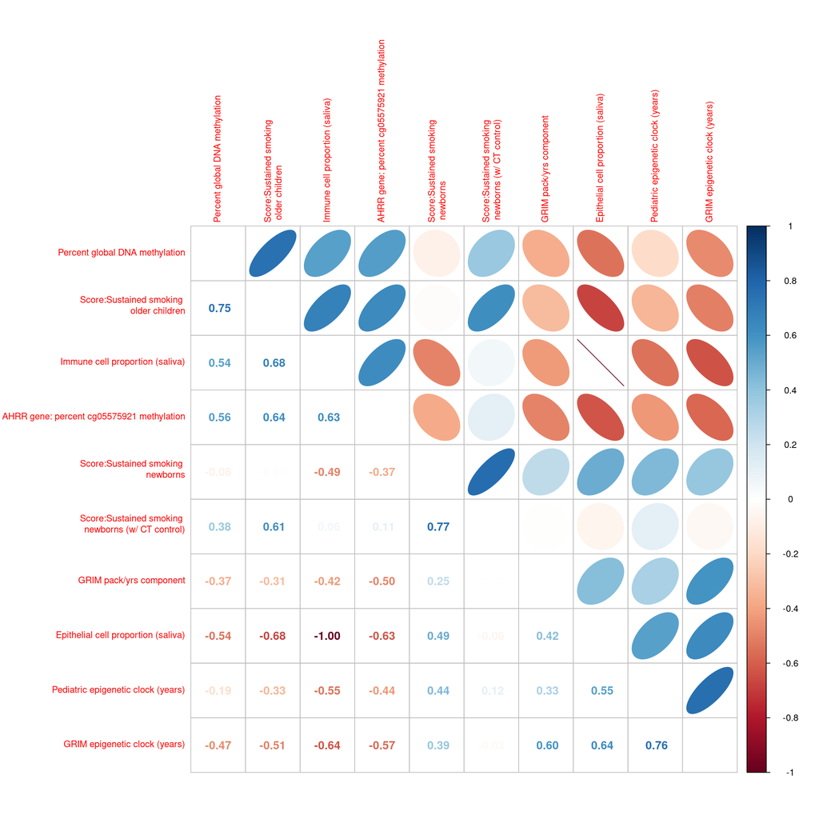

# Supplemental Figure 2 - Correlation between age 9 and age 15 visit DNA methylation summary measures among 694 children with age 9 and age 15 visit data in the Fragile Families and Child Wellbeing study. Each point represents one individual, x-axis is the DNA methylation summary measure at age 9 and y-axis is the DNA methylation measure at age 15. Blue lines are simple linear regression lines of best fit, with Pearson rho and associated $P$ value shown. From top-left: Polymethylation score for prenatal maternal smoking, score created using coefficients from a regression of prenatal maternal smoking and DNA methylation in newborn cord blood, incorporating cell-type control. Polymethylation score for prenatal maternal smoking using coefficients from a regression of prenatal maternal smoking and DNA methylation in newborn cord blood, no cell-type control. Polymethylation score calculated using regression coefficients from a regression of prenatal maternal smoking and DNA methylation in older children’s peripheral blood samples. Pediatric epigenetic clock (years). GRIM epigenetic clock (years). Percent DNA methylation at cg05575921 in AHRR. Percent global DNA methylation (mean across all DNA methylation sites in cleaned probe set). Proportion of epithelial cells calculated from DNA methylation using reference panel of children’s saliva. Proportion of immune cells calculated from DNA methylation using a reference panel of children’s saliva.

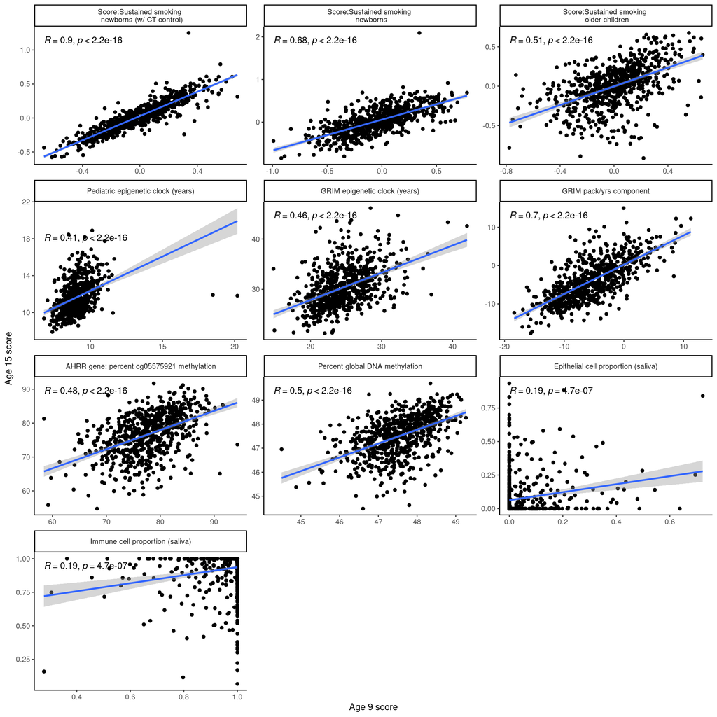

# Supplemental Figure 3: Distributions of selected methylation summary measures at age 9 and age 15 among 811 children in the Fragile Families and Child Wellbeing study. Captive box plots within violin plots show the distribution of selected DNA methylation measures in samples from age 9 (red) and age 15 (blue). Black lines show lines of best fit. From top-left: Polymethylation score for prenatal maternal smoking, score created using coefficients from a regression of prenatal maternal smoking and DNA methylation in newborn cord blood, incorporating cell-type control. Polymethylation score for prenatal maternal smoking using coefficients from a regression of prenatal maternal smoking and DNA methylation in newborn cord blood, no cell-type control. Polymethylation score calculated using regression coefficients from a regression of prenatal maternal smoking and DNA methylation in older children’s peripheral blood samples. Pediatric epigenetic clock (years). GRIM epigenetic clock (years). Percent DNA methylation at cg05575921 in AHRR. Percent global DNA methylation (mean across all DNA methylation sites in cleaned probe set). Proportion of epithelial cells calculated from DNA methylation using reference panel of children’s saliva. Proportion of immune cells calculated from DNA methylation using a reference panel of children’s saliva.

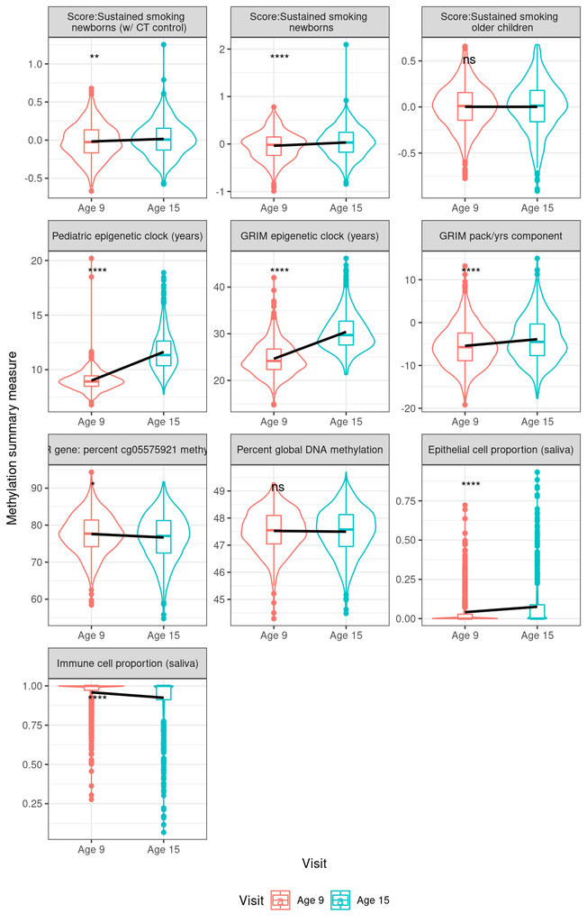

# Supplemental Table 2: Bivariate associations between prenatal maternal smoking and additional DNA methylation summary measures among a diverse sample of 811 children in the Fragile Families and Child Wellbeing study. Percent DNA methylation shown calculated across all DNA methylation sites available (global DNA methylation) and stratified by genomic region (Island, Open Sea, Shelf, Shore). Polymethylation score for smoke exposure from main analysis and from sensitivity analyses where scores were calculated using alternative available regression coefficients.

| **Characteristic** | **Age 9** **N** | **Age 9** **Not exposed**, N = 600<sup>1</sup> | **Age 9** **Smoke exposed**, N = 156<sup>1</sup> | **Age 9** **p-value**<sup>2</sup> | **Age 15** **N** | **Age 15** **Not exposed**, N = 605<sup>1</sup> | **Age 15** **Smoke exposed**, N = 144<sup>1</sup> | **Age 15** **p-value**<sup>2</sup> |
| --- | --- | --- | --- | --- | --- | --- | --- | --- |
| Percent global DNA methylation | 756 | 47.51 (0.74) | 47.59 (0.78) | 0.2 | 749 | 47.48 (0.85) | 47.58 (0.83) | 0.2 |
| Island methylation | 756 | 18.96 (0.61) | 19.07 (0.59) | 0.051 | 749 | 19.05 (0.61) | 19.14 (0.56) | 0.093 |
| Open Sea methylation | 756 | 70.36 (1.05) | 70.42 (1.10) | 0.5 | 749 | 70.22 (1.23) | 70.34 (1.22) | 0.3 |
| Shelf methylation | 756 | 75.33 (1.04) | 75.35 (1.10) | 0.8 | 749 | 75.19 (1.23) | 75.29 (1.21) | 0.4 |
| Shore methylation | 756 | 44.06 (0.82) | 44.17 (0.86) | 0.15 | 749 | 44.03 (0.94) | 44.15 (0.90) | 0.2 |
| Pediatric epigenetic clock (years) | 756 | 9.00 (0.85) | 9.01 (1.22) | 0.9 | 749 | 11.63 (1.77) | 11.64 (1.80) | >0.9 |
| GRIM epigenetic clock (years) | 756 | 24.7 (3.5) | 24.5 (3.3) | 0.6 | 749 | 30.5 (4.0) | 30.3 (4.2) | 0.6 |
| GRIM pack/yrs component | 756 | -5.6 (4.8) | -4.7 (5.0) | 0.041 | 749 | -4.0 (5.3) | -3.6 (5.1) | 0.4 |
| Epithelial cell proportion (saliva) | 756 | 0.04 (0.10) | 0.04 (0.08) | 0.3 | 749 | 0.08 (0.15) | 0.07 (0.14) | >0.9 |
| Immune cell proportion (saliva) | 756 | 0.96 (0.10) | 0.96 (0.08) | 0.3 | 749 | 0.92 (0.15) | 0.93 (0.14) | >0.9 |
| Polymethylation score for smoke exposure | 756 | -0.04 (0.22) | 0.09 (0.23) | <0.001 | 749 | -0.01 (0.22) | 0.11 (0.23) | <0.001 |
| Polymethylation score: coefficients for sustained smoking from newborn cordblood meta-analysis (mean-centered) | 756 | -0.06 (0.29) | 0.05 (0.27) | <0.001 | 749 | 0.01 (0.31) | 0.12 (0.31) | <0.001 |
| Polymethylation score: coeffcients for sustained smoking from older children peripheral blood meta-analysis (mean-centered) | 756 | -0.02 (0.23) | 0.09 (0.25) | <0.001 | 749 | -0.02 (0.27) | 0.07 (0.28) | <0.001 |
| Polymethylation score: coefficients for any smoking from newborn cordblood meta-analysis (mean-centered) | 756 | -0.04 (0.21) | 0.04 (0.19) | <0.001 | 749 | 0.01 (0.22) | 0.09 (0.22) | <0.001 |
| AHRR gene: percent cg05575921 methylation | 756 | 77.8 (5.2) | 76.8 (5.6) | 0.039 | 749 | 77 (6) | 76 (6) | 0.2 |
| MYO1G: cg04180046 | 756 | 35 (7) | 39 (8) | <0.001 | 749 | 35 (8) | 38 (8) | <0.001 |
| CYP1A1: cg05549655 | 756 | 18.7 (5.1) | 20.9 (5.5) | <0.001 | 749 | 18.3 (5.2) | 20.5 (5.1) | <0.001 |
| GFI1: cg14179389 | 756 | 5.70 (2.86) | 4.88 (2.62) | <0.001 | 749 | 5.74 (2.86) | 4.73 (1.78) | <0.001 |
| MYO1G: cg22132788 | 756 | 69 (10) | 73 (9) | <0.001 | 749 | 67 (11) | 70 (12) | 0.006 |

<sup>*1*</sup> Mean (SD) <sup>*2*</sup> Welch Two Sample t-test

# Supplemental Figure 4: Sensitivity analyses for controlling for different variable sets in multivariable analyses of prenatal maternal smoking and DNA methylation summary measures. Base model: Child sex, maternal income to poverty ratio, immune cell proportion, plate, 1st two principal components from PCA on child genetic data, child age. Prenatal exposures model: base model + yes/no any prenatal maternal alcohol use, yes/no any prenatal other drug use. Secondhand smoking models: prenatal exposures model + yes/no any postnatal maternal/primary care giver smoking at age 1 or 5, pk/day in month prior to primary caregiver/maternal interview at age 9 or 15. Surrogate variable: including all surrogate variables

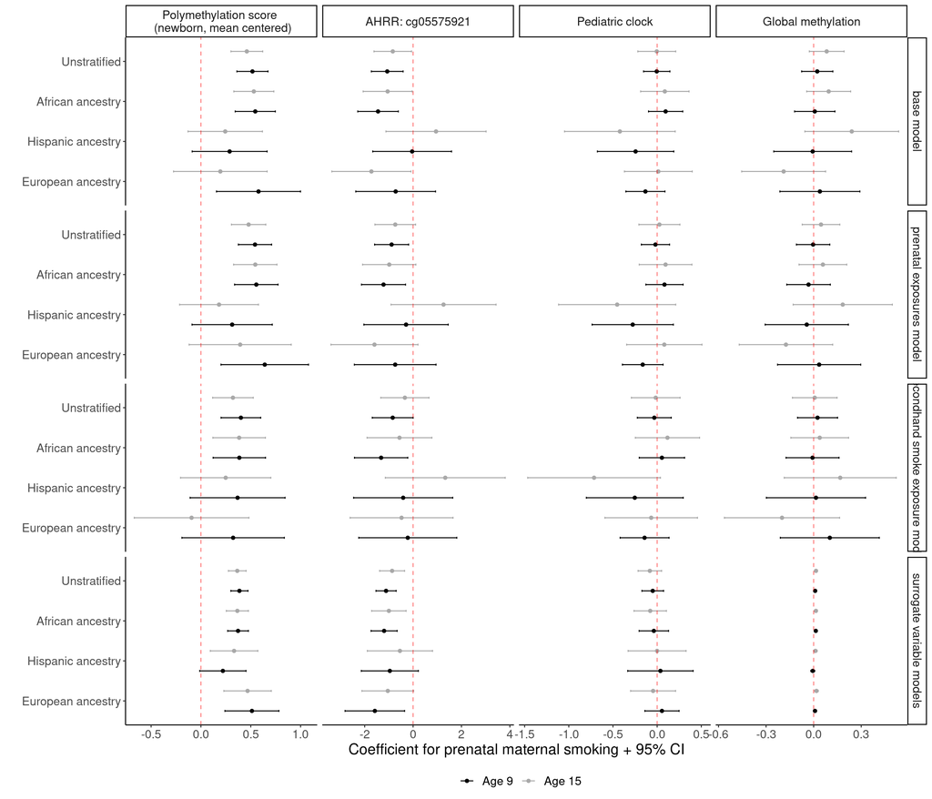

# Supplemental Figure 5 DNA methylation summary measures across combinations of exposure to prenatal and postnatal maternal smoking. Sample size is shown at the bottom of violin plots with captured boxplots. POlymethylation score shown in top facets, percent DNA methylation at cg05575921 in AHRR gene shown in bottom facets, age 9 samples shown in left facets, age 15 shown in right facets

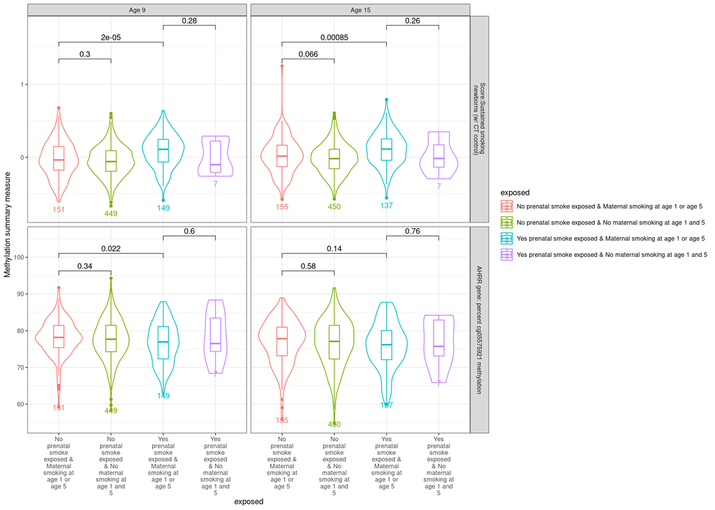

# Supplemental Figure 6: Heatmap of *P* values from Pearson correlations between known covariates and surrogate variables from surrogate variable models

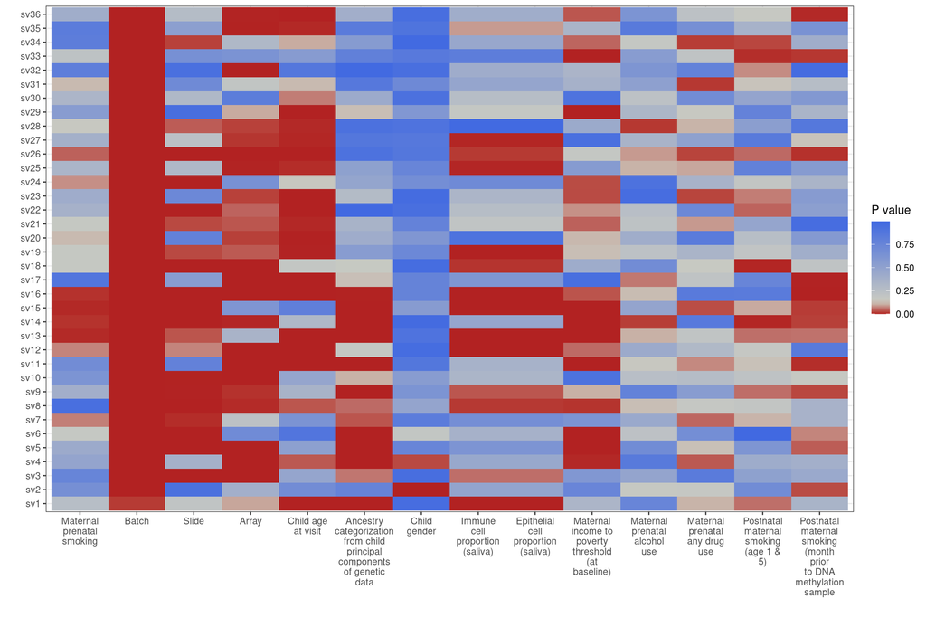

# Supplemental Table 3: Coefficients for multivariable models of prenatal maternal smoke exposure regressed on selected DNA methylation summary variables (outcomes) among children in the Fragile Families and Child Wellbeing study using surrogate variables

| **Characteristic** | Global methylation **N** | Global methylation **Beta** | Global methylation **95% CI**<sup>1</sup> | Global methylation **p-value** | Pediatric clock **N** | Pediatric clock **Beta** | Pediatric clock **95% CI**<sup>1</sup> | Pediatric clock **p-value** | Sustained smoking polymethylation score (newborns, cell-type controlled) **N** | Sustained smoking polymethylation score (newborns, cell-type controlled) **Beta** | Sustained smoking polymethylation score (newborns, cell-type controlled) **95% CI**<sup>1</sup> | Sustained smoking polymethylation score (newborns, cell-type controlled) **p-value** | AHRR: cg05575921 **N** | AHRR: cg05575921 **Beta** | AHRR: cg05575921 **95% CI**<sup>1</sup> | AHRR: cg05575921 **p-value** |
| --- | --- | --- | --- | --- | --- | --- | --- | --- | --- | --- | --- | --- | --- | --- | --- | --- |
| African ancestry |  |  |  |  |  |  |  |  |  |  |  |  |  |  |  |  |
| Prenatal maternal smoke exposed | 905 | 0.01 | 0.01, 0.02 | <0.001 | 905 | -0.17 | -0.36, 0.02 | 0.084 | 905 | 0.40 | 0.30, 0.50 | <0.001 | 905 | -1.1 | -1.6, -0.59 | <0.001 |
| European ancestry |  |  |  |  |  |  |  |  |  |  |  |  |  |  |  |  |
| Prenatal maternal smoke exposed | 234 | 0.01 | 0.01, 0.02 | <0.001 | 234 | 0.03 | -0.19, 0.24 | 0.8 | 234 | 0.60 | 0.38, 0.81 | <0.001 | 234 | -1.1 | -1.9, -0.36 | 0.004 |
| Hispanic ancestry |  |  |  |  |  |  |  |  |  |  |  |  |  |  |  |  |
| Prenatal maternal smoke exposed | 362 | 0.00 | -0.01, 0.01 | 0.4 | 362 | -0.05 | -0.38, 0.27 | 0.7 | 362 | 0.36 | 0.16, 0.55 | <0.001 | 362 | -0.56 | -1.5, 0.37 | 0.2 |
| Unstratified |  |  |  |  |  |  |  |  |  |  |  |  |  |  |  |  |
| Prenatal maternal smoke exposed | 1501 | 0.01 | 0.01, 0.02 | <0.001 | 1501 | -0.14 | -0.27, 0.00 | 0.056 | 1501 | 0.42 | 0.33, 0.50 | <0.001 | 1501 | -0.95 | -1.3, -0.58 | <0.001 |

<sup>*1*</sup> CI = Confidence Interval

# Supplemental Table 4: Associations between prenatal maternal smoking and DNA methylation summary measures in multivariable linear models stratified by age or in multivariable linear mixed effect models among 811 US children. All models controlled for: first two principal components of child genetic ancestry (recalculated within ancestry strata for stratified models), child sex, maternal income-to-poverty ratio at birth, immune cell proportion estimated from methylation data, child age

| **Characteristic** | Global methylation **N** | Global methylation **Beta** | Global methylation **95% CI**<sup>1</sup> | Global methylation **p-value** | Pediatric clock **N** | Pediatric clock **Beta** | Pediatric clock **95% CI**<sup>1</sup> | Pediatric clock **p-value** | Sustained smoking polymethylation score (newborns, cell-type controlled) **N** | Sustained smoking polymethylation score (newborns, cell-type controlled) **Beta** | Sustained smoking polymethylation score (newborns, cell-type controlled) **95% CI**<sup>1</sup> | Sustained smoking polymethylation score (newborns, cell-type controlled) **p-value** | AHRR: cg05575921 **N** | AHRR: cg05575921 **Beta** | AHRR: cg05575921 **95% CI**<sup>1</sup> | AHRR: cg05575921 **p-value** |
| --- | --- | --- | --- | --- | --- | --- | --- | --- | --- | --- | --- | --- | --- | --- | --- | --- |
| Age 9 models |  |  |  |  |  |  |  |  |  |  |  |  |  |  |  |  |
| Prenatal maternal smoke exposed | 756 | 0.02 | -0.08, 0.12 | 0.7 | 756 | 0.00 | -0.15, 0.14 | >0.9 | 756 | 0.52 | 0.36, 0.67 | <0.001 | 756 | -1.1 | -1.7, -0.41 | 0.001 |
| Age 15 models |  |  |  |  |  |  |  |  |  |  |  |  |  |  |  |  |
| Prenatal maternal smoke exposed | 749 | 0.08 | -0.03, 0.19 | 0.14 | 749 | 0.00 | -0.22, 0.21 | >0.9 | 749 | 0.46 | 0.30, 0.62 | <0.001 | 749 | -0.84 | -1.6, -0.06 | 0.034 |
| Longitudinal models |  |  |  |  |  |  |  |  |  |  |  |  |  |  |  |  |
| Prenatal maternal smoke exposed | 1505 | 0.05 | -0.03, 0.14 | 0.2 | 1505 | 0.02 | -0.12, 0.17 | 0.8 | 1505 | 0.48 | 0.34, 0.63 | <0.001 | 1505 | -1.0 | -1.5, -0.39 | 0.001 |

<sup>*1*</sup> CI = Confidence Interval